# model

## Deep Learning: Image Captioning using VGG16 and Customized LSTM Neural Network Model

## Importing Necessary Libraries

```python
# Import necessary libraries
import os  # Operating system-specific functionality
import pickle  # Serialization and deserialization of Python objects
import numpy as np  # Numerical operations
import matplotlib.pyplot as plt  # Plotting library
from PIL import Image  # Python Imaging Library for image processing
from math import ceil  # Ceiling function for calculating steps_per_epoch
from collections import defaultdict  # Default dictionary for convenient data structure
```

```python
# Import the TensorFlow library
import tensorflow as tf  # High-level machine learning library

# Import the VGG16 model and related modules from Keras
from tensorflow.keras.applications.vgg16 import VGG16, preprocess_input  # VGG16 model and preprocessing functions
from tensorflow.keras.preprocessing.image import load_img, img_to_array  # Image loading and conversion utilities
```

```python
# Import the Tokenizer class from Keras for text tokenization
from tensorflow.keras.preprocessing.text import Tokenizer  # Tokenizer for text data

# Import the pad_sequences function from Keras for sequence padding
from tensorflow.keras.preprocessing.sequence import pad_sequences  # Function for padding sequences to a fixed length
```

```python
# Import the Model and load_model classes from Keras for model building and loading
from tensorflow.keras.models import Model, load_model  # Model-related functionalities

# Import the to_categorical function from Keras for one-hot encoding
from tensorflow.keras.utils import to_categorical  # Utility function for one-hot encoding

# Import specific layers and utilities from Keras
from tensorflow.keras.layers import *  # Importing various layers like Dense, Dropout, etc.
```

```python
# Import the corpus_bleu function from NLTK for calculating BLEU scores
from nltk.translate.bleu_score import corpus_bleu  # BLEU score calculation using NLTK
```

## Flickr8k Dataset Overview

The Flickr8k Dataset is a widely used collection in the field of image captioning. It consists of 8,000 images gathered from the photo-sharing platform Flickr. Each image is accompanied by five descriptive captions, providing rich and diverse textual descriptions for various scenes and subjects.

The dataset covers a broad range of subjects, including people, animals, objects, and scenic views. Each image is a snapshot of a moment, and the five captions associated with it capture different aspects and interpretations.

## Setting the Input and Output Directory Path

```python
# Specify the input directory path
INPUT_DIR = './dataset/'  # Directory where the input data is stored

# Specify the output directory path
OUTPUT_DIR = './models/'  # Directory where the output models will be saved
```

## Transfer Learning using Pre-trained VGG16 Model

```python
# Utilizing a pre-trained VGG16 model for feature extraction
# Loading the VGG16 model with pre-trained weights
# Specify the parameters
weights = 'imagenet'  # Use pre-trained weights from ImageNet
include_top = True     # Include the fully connected layers at the top of the network
input_shape = (224, 224, 3)  # Input shape of the images

# Create the VGG16 model with the specified parameters
model = VGG16(weights=weights, include_top=include_top, input_shape=input_shape)

# Modifying the model structure to exclude the final classification layer, enabling access to the model's output features
model = Model(inputs=model.inputs, outputs=model.layers[-2].output)

# Displaying a summary of the modified model
model.summary()
```

```
Model: "model"
_________________________________________________________________
 Layer (type)                Output Shape              Param #
=================================================================
 input_1 (InputLayer)        [(None, 224, 224, 3)]     0

 block1_conv1 (Conv2D)       (None, 224, 224, 64)      1792

 block1_conv2 (Conv2D)       (None, 224, 224, 64)      36928

 block1_pool (MaxPooling2D)  (None, 112, 112, 64)      0

 block2_conv1 (Conv2D)       (None, 112, 112, 128)     73856

 block2_conv2 (Conv2D)       (None, 112, 112, 128)     147584

 block2_pool (MaxPooling2D)  (None, 56, 56, 128)       0

 block3_conv1 (Conv2D)       (None, 56, 56, 256)       295168

 block3_conv2 (Conv2D)       (None, 56, 56, 256)       590080

 block3_conv3 (Conv2D)       (None, 56, 56, 256)       590080

 block3_pool (MaxPooling2D)  (None, 28, 28, 256)       0

 block4_conv1 (Conv2D)       (None, 28, 28, 512)       1180160

 block4_conv2 (Conv2D)       (None, 28, 28, 512)       2359808

 block4_conv3 (Conv2D)       (None, 28, 28, 512)       2359808

 block4_pool (MaxPooling2D)  (None, 14, 14, 512)       0

 block5_conv1 (Conv2D)       (None, 14, 14, 512)       2359808

 block5_conv2 (Conv2D)       (None, 14, 14, 512)       2359808

 block5_conv3 (Conv2D)       (None, 14, 14, 512)       2359808

 block5_pool (MaxPooling2D)  (None, 7, 7, 512)         0

 flatten (Flatten)           (None, 25088)             0

 fc1 (Dense)                 (None, 4096)              102764544

 fc2 (Dense)                 (None, 4096)              16781312

=================================================================
Total params: 134,260,544
Trainable params: 134,260,544
Non-trainable params: 0
_________________________________________________________________
None
```

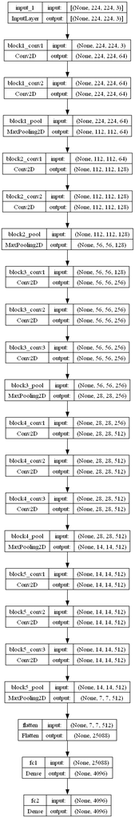

```python
# Visualizing the architecture of the specified model
# Plotting the model with shapes included for a clearer understanding of layer dimensions
plot_model(model, show_shapes=True)
```

#### Model Architecture

- The model takes images of size (224, 224, 3) as input.
- The convolutional layers (block1_conv1, block1_conv2, ..., block5_conv3) extract hierarchical features from the input images.
- MaxPooling layers (block1_pool, block2_pool, ..., block5_pool) reduce spatial dimensions while retaining essential features.
- The Flatten layer transforms the 3D output to a 1D vector for the fully connected layers.
- The fully connected layers (fc1, fc2) contribute to the classification process with a large number of parameters.
- The model has a total of 134,260,544 parameters, all of which are trainable.

As I delve into the depths of this VGG16 model, it's fascinating to see the progression of features through convolutional layers and the richness of parameters contributing to its understanding of diverse visual patterns.

### The VGG16 Model

VGG16, short for the Visual Geometry Group's 16-layer model, stands out for its simplicity and effectiveness in image classification tasks. Comprising 16 weight layers, it has a straightforward structure with small, 3x3 convolutional filters stacked on top of each other.

Here's a breakdown of its key components:

### Convolutional Blocks

- **Block 1 to Block 5:** These sequential blocks consist of convolutional layers (blockX_convY) and max-pooling layers (blockX_pool). Each block gradually abstracts higher-level features from the input image.

### Fully Connected Layers

- **Flatten Layer:** Flattens the output from convolutional layers into a one-dimensional vector.
- **Fully Connected Layers (fc1, fc2):** Dense layers that contribute to the final classification. These layers contain a large number of parameters, enabling the model to learn intricate patterns.

### Total Parameters

VGG16 boasts a substantial parameter count, totaling 134,260,544. Every parameter plays a crucial role in the model's ability to understand and differentiate between various visual patterns.

## Why VGG16?

### Simplicity and Elegance

I appreciate the elegance of VGG16's architecture. The repeated pattern of small convolutional filters facilitates feature extraction, making it easy to comprehend and implement.

### Strong Performance

While VGG16 may not be the most lightweight model, its performance on image classification tasks, especially when pre-trained on large datasets like ImageNet, is remarkable. The learned features can be valuable for diverse computer vision applications.

### Versatility

The versatility of VGG16 extends beyond classification. Its hierarchical feature extraction makes it suitable for tasks like feature extraction and transfer learning, aligning well with the goals of my current project.

As I navigate through the intricacies of deep learning, VGG16 serves as a reliable companion, offering both simplicity in design and strength in performance. Its contribution to my image captioning endeavor lies in its ability to comprehend the intricate details of images, laying the foundation for crafting rich and meaningful captions.patterns.

## Image Preprocessing and Image Feature Extraction

[figure not shown]

```python
# Create an empty dictionary to hold the extracted features of images
image_features = {}

# Specify the directory path where the images are stored
img_dir = os.path.join(INPUT_DIR, 'Images')

# Iterate through each image in the directory
for img_name in os.listdir(img_dir):
    # Load the image from the file
    img_path = os.path.join(img_dir, img_name)
    loaded_image = load_img(img_path, target_size=(224, 224))

    # Convert the image pixels to a NumPy array
    image_array = img_to_array(loaded_image)

    # Reshape the data to match the model's input requirements
    reshaped_image = image_array.reshape((1, image_array.shape[0], image_array.shape[1], image_array.shape[2]))

    # Perform preprocessing specific to the VGG16 model
    preprocessed_image = preprocess_input(reshaped_image)

    # Extract features using the pre-trained VGG16 model
    extracted_feature = model.predict(preprocessed_image, verbose=0)

    # Obtain the image ID by removing the file extension
    image_id = img_name.split('.')[0]

    # Store the extracted feature in the dictionary with the image ID as the key
    image_features[image_id] = extracted_feature
```

### Saving the Image Features Using Pickle

```python
# Serialize and save the extracted image features using the pickle module
# Combine the output directory path with the desired file name
output_file_path = os.path.join(OUTPUT_DIR, 'new_img_features.pkl')
# Open the file for writing in binary mode
with open(output_file_path, 'wb') as file:
    # Use pickle to store the image features in the specified file
    pickle.dump(image_features, file)
```

### Loading the Image Features Using Pickle

```python
# Specify the file path for the pickled image features
pickle_file_path = os.path.join(OUTPUT_DIR, 'new_img_features.pkl')

# Open the file for reading in binary mode
with open(pickle_file_path, 'rb') as file:
    # Load the stored image features from the specified file using pickle
    loaded_features = pickle.load(file)
```

## Image Caption Preprocessing

```python
# Open and read the contents of the 'captions.txt' file located in the input directory
with open(os.path.join(INPUT_DIR, 'captions.txt'), 'r') as file:
    # Skip the header line and read the remaining content
    next(file)
    captions_doc = file.read()
```

```python
# Create a defaultdict to store lists of captions associated with each image
image_to_captions_mapping = defaultdict(list)
```

```python
# Iterate through each line in the captions document
for line in captions_doc.split('\n'):
    # Split the line into tokens using a comma as a delimiter
    tokens = line.split(',')

    # Check if the number of tokens is less than 2, and continue to the next iteration if true
    if len(tokens) < 2:
        continue

    # Extract image ID and captions from the tokens
    image_id, *captions = tokens

    # Remove the file extension from the image ID
    image_id = image_id.split('.')[0]

    # Join the remaining tokens to form the complete caption
    caption = " ".join(captions)

    # Append the caption to the list associated with the image ID in the mapping
    image_to_captions_mapping[image_id].append(caption)

# Calculate and print the total number of captions
total_captions = sum(len(captions) for captions in image_to_captions_mapping.values())
print("Total Number of Captions:", total_captions)
```

```
Total Number of Captions: 40455
```

```python
def clean(mapping):
    """
    Clean and preprocess captions in the given mapping.

    Args:
    - mapping (dict): A dictionary mapping image IDs to lists of captions.

    Returns:
    - None: The function modifies the captions in-place.
    """
    for key, captions in mapping.items():
        for i in range(len(captions)):
            caption = captions[i]

            # Convert to lowercase
            caption = caption.lower()

            # Remove non-alphabetic characters except spaces
            caption = ''.join(char for char in caption if char.isalpha() or char.isspace())

            # Replace multiple spaces with a single space
            caption = caption.replace('\s+', ' ')

            # Add start and end tokens to the caption
            caption = 'startseq ' + ' '.join([word for word in caption.split() if len(word) > 1]) + ' endseq'

            # Update the caption in the list
            captions[i] = caption
```

```python
# Before Text Preprocessing
image_to_captions_mapping['3637013_c675de7705']
```

```
["A couple stands close at the water 's edge .",
 'The two people stand by a body of water and in front of bushes in fall .',
 'Two people hold each other near a pond .',
 'Two people stand by the water .',
 'Two people stand together on the edge of the water on the grass .']
```

```python
# Text Preprocessing Step
clean(image_to_captions_mapping)
```

```python
image_to_captions_mapping['3637013_c675de7705']
```

```
['startseq couple stands close at the water edge endseq',
 'startseq the two people stand by body of water and in front of bushes in fall endseq',
 'startseq two people hold each other near pond endseq',
 'startseq two people stand by the water endseq',
 'startseq two people stand together on the edge of the water on the grass endseq']
```

```python
all_captions = [caption for captions in image_to_captions_mapping.values() for caption in captions]
```

```python
all_captions[:10]
```

```
['startseq child in pink dress is climbing up set of stairs in an entry way endseq',
 'startseq girl going into wooden building endseq',
 'startseq little girl climbing into wooden playhouse endseq',
 'startseq little girl climbing the stairs to her playhouse endseq',
 'startseq little girl in pink dress going into wooden cabin endseq',
 'startseq black dog and spotted dog are fighting endseq',
 'startseq black dog and tricolored dog playing with each other on the road endseq',
 'startseq black dog and white dog with brown spots are staring at each other in the street endseq',
 'startseq two dogs of different breeds looking at each other on the road endseq',
 'startseq two dogs on pavement moving toward each other endseq']
```

## Tokenizing Image Caption

```python
# Create a Tokenizer object
tokenizer = Tokenizer()

# Fit the Tokenizer on the list of all captions to build the vocabulary
tokenizer.fit_on_texts(all_captions)
```

```python
# Serialize and save the Tokenizer object using pickle
with open('tokenizer.pkl', 'wb') as tokenizer_file:
    pickle.dump(tokenizer, tokenizer_file)
```

```python
# Deserialize and load the Tokenizer object from the saved file using pickle
with open('tokenizer.pkl', 'rb') as tokenizer_file:
    tokenizer = pickle.load(tokenizer_file)
```

```python
# Determine the maximum caption length among all captions using the Tokenizer
max_caption_length = max(len(tokenizer.texts_to_sequences([caption])[0]) for caption in all_captions)

# Calculate the vocabulary size based on the Tokenizer's word index
vocab_size = len(tokenizer.word_index) + 1

# Print the calculated vocabulary size and maximum caption length
print("Vocabulary Size:", vocab_size)
print("Maximum Caption Length:", max_caption_length)
```

```
Vocabulary Size: 8768
Maximum Caption Length: 34
```

## Splitting the Dataset into the Training Set and The Testing Set

```python
# Create a list of image IDs from the keys of the image_to_captions_mapping dictionary
image_ids = list(image_to_captions_mapping.keys())
```

```python
# Determine the split index for creating training and test sets
split = int(len(image_ids) * 0.90)

# Create the training set by selecting the first 90% of image IDs
train = image_ids[:split]

# Create the test set by selecting the remaining 10% of image IDs
test = image_ids[split:]
```

```python
# Generator function for training data
def data_generator(train_keys, img_to_caps_mapping, img_features, tokenizer, max_cap_length, vocab_size, batch_size):
    """
    Generates batches of training data for the image captioning model.

    Args:
    - train_keys (list): List of image keys for the training set.
    - img_to_caps_mapping (dict): Dictionary mapping image keys to associated captions.
    - img_features (dict): Dictionary containing image features extracted using a pre-trained model.
    - tokenizer (Tokenizer): Tokenizer object for text tokenization.
    - max_cap_length (int): Maximum length of captions after tokenization.
    - vocab_size (int): Size of the vocabulary.
    - batch_size (int): Size of each training batch.

    Yields:
    - tuple: Tuple containing input data (image features and input sequences) and target output sequences.
    """
    # Lists to store batch data
    X1_batch, X2_batch, y_batch = [], [], []
    # Counter for the current batch size
    batch_count = 0

    while True:
        # Loop through each image in the current batch
        for img_key in train_keys:
            # Get the captions associated with the current image
            captions = img_to_caps_mapping[img_key]

            # Loop through each caption for the current image
            for caption in captions:
                # Convert the caption to a sequence of token IDs
                caption_seq = tokenizer.texts_to_sequences([caption])[0]

                # Loop through the tokens in the caption sequence
                for i in range(1, len(caption_seq)):
                    # Split the sequence into input and output pairs
                    in_seq, out_seq = caption_seq[:i], caption_seq[i]

                    # Pad the input sequence to the specified maximum caption length
                    in_seq = pad_sequences([in_seq], maxlen=max_cap_length)[0]

                    # Convert the output sequence to one-hot encoded format
                    out_seq = to_categorical([out_seq], num_classes=vocab_size)[0]

                    # Append data to batch lists
                    X1_batch.append(img_features[img_key][0])  # Image features
                    X2_batch.append(in_seq)  # Input sequence
                    y_batch.append(out_seq)  # Output sequence

                    # Increase the batch counter
                    batch_count += 1

                    # If the batch is complete, yield the batch and reset lists and counter
                    if batch_count == batch_size:
                        X1_batch, X2_batch, y_batch = np.array(X1_batch), np.array(X2_batch), np.array(y_batch)
                        yield [X1_batch, X2_batch], y_batch
                        X1_batch, X2_batch, y_batch = [], [], []
                        batch_count = 0
```

## Building Customized LSTM Neural Network

```python
# Encoder model
inputs1 = Input(shape=(4096,))
fe1 = Dropout(0.5)(inputs1)
fe2 = Dense(256, activation='relu')(fe1)
fe2_projected = RepeatVector(max_caption_length)(fe2)
fe2_projected = Bidirectional(LSTM(256, return_sequences=True))(fe2_projected)

# Sequence feature layers
inputs2 = Input(shape=(max_caption_length,))
se1 = Embedding(vocab_size, 256, mask_zero=True)(inputs2)
se2 = Dropout(0.5)(se1)
se3 = Bidirectional(LSTM(256, return_sequences=True))(se2)

# Apply attention mechanism using Dot product
attention = Dot(axes=[2, 2])([fe2_projected, se3])  # Calculate attention scores

# Softmax attention scores
attention_scores = Activation('softmax')(attention)

# Apply attention scores to sequence embeddings
attention_context = Lambda(lambda x: tf.einsum('ijk,ijl->ikl', x[0], x[1]))([attention_scores, se3])

# Sum the attended sequence embeddings along the time axis
context_vector = tf.reduce_sum(attention_context, axis=1)

# Decoder model
decoder_input = concatenate([context_vector, fe2], axis=-1)
decoder1 = Dense(256, activation='relu')(decoder_input)
outputs = Dense(vocab_size, activation='softmax')(decoder1)

# Create the model
model = Model(inputs=[inputs1, inputs2], outputs=outputs)
model.compile(loss='categorical_crossentropy', optimizer='adam')

# Visualize the model
model.summary()
```

```
Model: "model_1"
__________________________________________________________________________________________________
 Layer (type)                   Output Shape         Param #     Connected to
==================================================================================================
 input_3 (InputLayer)           [(None, 4096)]       0           []

 dropout_1 (Dropout)            (None, 4096)         0           ['input_3[0][0]']

 input_4 (InputLayer)           [(None, 34)]         0           []

 dense_1 (Dense)                (None, 256)          1048832     ['dropout_1[0][0]']

 embedding (Embedding)          (None, 34, 256)      2244608     ['input_4[0][0]']

 repeat_vector (RepeatVector)   (None, 34, 256)      0           ['dense_1[0][0]']

 dropout_2 (Dropout)            (None, 34, 256)      0           ['embedding[0][0]']

 bidirectional (Bidirectional)  (None, 34, 512)      1050624     ['repeat_vector[0][0]']

 bidirectional_1 (Bidirectional  (None, 34, 512)     1050624     ['dropout_2[0][0]']
 )

 dot (Dot)                      (None, 34, 34)       0           ['bidirectional[0][0]',
                                                                  'bidirectional_1[0][0]']

 activation (Activation)        (None, 34, 34)       0           ['dot[0][0]']

 lambda (Lambda)                (None, 34, 512)      0           ['activation[0][0]',
                                                                  'bidirectional_1[0][0]']

 tf.math.reduce_sum (TFOpLambda  (None, 512)         0           ['lambda[0][0]']
 )

 concatenate (Concatenate)      (None, 768)          0           ['tf.math.reduce_sum[0][0]',
                                                                  'dense_1[0][0]']

 dense_2 (Dense)                (None, 256)          196864      ['concatenate[0][0]']

 dense_3 (Dense)                (None, 8768)         2253376     ['dense_2[0][0]']

==================================================================================================
Total params: 7,844,928
Trainable params: 7,844,928
Non-trainable params: 0
__________________________________________________________________________________________________
```

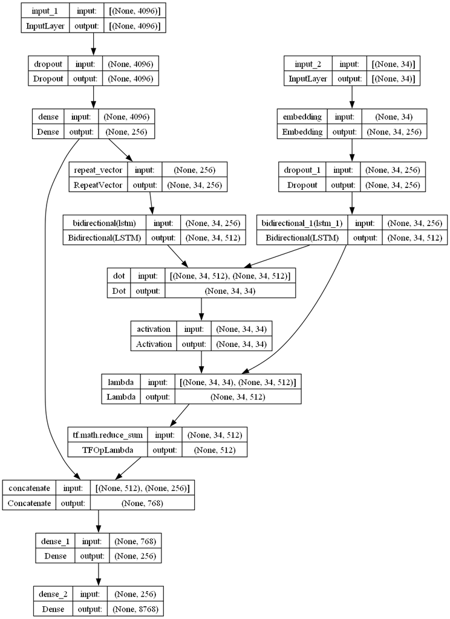

```python
# Visualize the model architecture with shapes
plot_model(model, show_shapes=True)
```

#### Layers and Connections

1. **Input Layers:**
   - **input_3 (4096):** Represents the image features as a vector of size 4096.
   - **input_4 (34):** Represents the tokenized sequence of words in the caption.
2. **Dropout Layer (dropout_1):**
   - Applies dropout regularization to the image features.
3. **Dense Layer (dense_1):**
   - Outputs a vector of size 256 from the processed image features.
4. **Embedding Layer (embedding):**
   - Converts the tokenized word sequence into vectors of size 256.
5. **RepeatVector Layer (repeat_vector):**
   - Repeats the vector representation of image features to match the length of the caption sequence.
6. **Dropout Layer (dropout_2):**
   - Applies dropout regularization to the embedded word sequence.
7. **Bidirectional LSTM Layers (bidirectional, bidirectional_1):**
   - Processes the repeated image features and the embedded word sequence bidirectionally, capturing context.
8. **Dot Layer (dot):**
   - Calculates dot product attention scores between the two bidirectional LSTM outputs.
9. **Activation Layer (activation):**
   - Applies softmax activation to obtain attention weights.
10. **Lambda Layer (lambda):**
    - Computes the weighted sum of bidirectional LSTM outputs based on attention weights.
11. **Reduce Sum Layer (tf.math.reduce_sum):**
    - Reduces the sequence of weighted sums along the time axis.
12. **Concatenate Layer (concatenate):**
    - Concatenates the reduced sum with the vector output from the dense layer.
13. **Dense Layers (dense_2, dense_3):**
    - Further processes the concatenated vector to generate the final output, predicting the next word in the sequence.

#### Total Parameters

- **Total parameters:** 7,844,928
- **Trainable parameters:** 7,844,928
- **Non-trainable parameters:** 0

This architecture is carefully designed to combine image features and sequential information for accurate and context-aware caption generation. The total parameters reflect the model's capacity to learn and generalize from diverse image and caption data during training.

## Training the LSTM Neural Network

```python
# Set the number of training epochs and batch size
epochs = 50
batch_size = 32

# Calculate the steps per epoch based on the number of batches in one epoch
steps_per_epoch = ceil(len(train) / batch_size)
validation_steps = ceil(len(test) / batch_size)  # Calculate the steps for validation data

# Loop through the epochs for training
for epoch in range(epochs):
    print(f"Epoch {epoch + 1}/{epochs}")

    # Set up data generators for training and validation
    train_generator = data_generator(train, image_to_captions_mapping, loaded_features, tokenizer, max_caption_length, vocab_size, batch_size)
    validation_generator = data_generator(test, image_to_captions_mapping, loaded_features, tokenizer, max_caption_length, vocab_size, batch_size)

    # Train the model for one epoch using the data generators
    model.fit(train_generator, epochs=1, steps_per_epoch=steps_per_epoch,
              validation_data=validation_generator, validation_steps=validation_steps,
              verbose=1)
```

### Saving and Loading the LSTM Model

```python
# Save the trained model to a file
model.save(os.path.join(OUTPUT_DIR, 'mymodel.h5'))
```

```python
# Load the trained model from the saved file
model = load_model(os.path.join(OUTPUT_DIR, 'mymodel.h5'))
```

## Predicting Image Caption Given the Image

```python
def get_word_from_index(index, tokenizer):
    """
    Retrieve the word corresponding to a given index from the tokenizer's vocabulary.

    Args:
    - index (int): Index of the word.
    - tokenizer (Tokenizer): Tokenizer object.

    Returns:
    - str or None: The word corresponding to the index, or None if not found.
    """
    return next((word for word, idx in tokenizer.word_index.items() if idx == index), None)
```

```python
def predict_caption(model, image_features, tokenizer, max_caption_length):
    """
    Generate a descriptive caption for a given image using the provided image captioning model.

    Args:
    - model (Model): Trained image captioning model.
    - image_features (numpy.ndarray): Extracted features of the input image.
    - tokenizer (Tokenizer): Tokenizer object used for text tokenization.
    - max_caption_length (int): Maximum length of the generated caption.

    Returns:
    - str: Predicted caption for the input image.
    """
    # Initialize the caption sequence
    caption = 'startseq'

    # Generate the caption
    for _ in range(max_caption_length):
        # Convert the current caption to a sequence of token indices
        sequence = tokenizer.texts_to_sequences([caption])[0]
        # Pad the sequence to match the maximum caption length
        sequence = pad_sequences([sequence], maxlen=max_caption_length)
        # Predict the probability distribution for the next word
        y_hat = model.predict([image_features, sequence], verbose=0)
        # Get the index with the highest predicted probability
        predicted_index = np.argmax(y_hat)
        # Convert the index to a word
        predicted_word = get_word_from_index(predicted_index, tokenizer)

        # Append the predicted word to the caption
        caption += " " + predicted_word

        # Stop if the predicted word is None or if the end sequence tag is encountered
        if predicted_word is None or predicted_word == 'endseq':
            break

    return caption
```

### Evaluating BLEU Scores

```python
# Initialize lists to store actual and predicted captions
actual_captions_list = []
predicted_captions_list = []

# Loop through the test data
for key in test:
    # Retrieve actual captions for the current image
    actual_captions = image_to_captions_mapping[key]
    # Generate a caption for the image using the trained model
    predicted_caption = predict_caption(model, loaded_features[key], tokenizer, max_caption_length)

    # Split actual captions into individual words
    actual_captions_words = [caption.split() for caption in actual_captions]
    # Split the predicted caption into words
    predicted_caption_words = predicted_caption.split()

    # Append the word lists to their respective lists
    actual_captions_list.append(actual_captions_words)
    predicted_captions_list.append(predicted_caption_words)

# Calculate BLEU scores for unigram and bigram precision
bleu_score_1 = corpus_bleu(actual_captions_list, predicted_captions_list, weights=(1.0, 0, 0, 0))
bleu_score_2 = corpus_bleu(actual_captions_list, predicted_captions_list, weights=(0.5, 0.5, 0, 0))

print("BLEU-1 Score: %f" % bleu_score_1)
print("BLEU-2 Score: %f" % bleu_score_2)
```

[output not shown]

### Saving and Loading the Actual and Predicted Image Caption

```python
# Save the lists of actual captions using pickle
with open('actual_captions_list.pkl', 'wb') as actual_file:
    pickle.dump(actual_captions_list, actual_file)

# Save the lists of predicted captions using pickle
with open('predicted_captions_list.pkl', 'wb') as predicted_file:
    pickle.dump(predicted_captions_list, predicted_file)
```

```python
# Load actual captions list
with open('actual_captions_list.pkl', 'rb') as file:
    loaded_actual_captions_list = pickle.load(file)

# Load predicted captions list
with open('predicted_captions_list.pkl', 'rb') as file:
    loaded_predicted_captions_list = pickle.load(file)
```

```python
def generate_caption(image_name):
    """
    Display actual and predicted captions for a given image along with its visual representation.

    Args:
    - image_name (str): Name of the image file.

    Returns:
    - None
    """
    # Extract image ID from the image name
    image_id = image_name.split('.')[0]
    # Get the full path of the image file
    img_path = os.path.join(INPUT_DIR, "Images", image_name)
    # Open the image using the PIL library
    image = Image.open(img_path)
    # Retrieve actual captions for the image
    captions = image_to_captions_mapping[image_id]

    print('---------------------Actual---------------------')
    # Display actual captions
    for caption in captions:
        print(caption)

    # Generate and display the predicted caption
    y_pred = predict_caption(model, loaded_features[image_id], tokenizer, max_caption_length)
    print('--------------------Predicted--------------------')
    print(y_pred)

    # Display the image
    plt.imshow(image)
```

## Displaying Predicted Image Caption

```
---------------------Actual---------------------
startseq man in hat is displaying pictures next to skier in blue hat endseq
startseq man skis past another man displaying paintings in the snow endseq
startseq person wearing skis looking at framed pictures set up in the snow endseq
startseq skier looks at framed pictures in the snow next to trees endseq
startseq man on skis looking at artwork for sale in the snow endseq
--------------------Predicted--------------------
startseq man on skis looking at artwork for sale in the snow endseq
```

[figure not shown]

```python
generate_caption("101669240_b2d3e7f17b.jpg")
```

```
---------------------Actual---------------------
startseq boy in blue shorts slides down slide into pool endseq
startseq boy in blue swimming trunks slides down yellow slide into wading pool with inflatable toys floating in the water endseq
startseq boy rides down slide into small backyard pool endseq
startseq boy sliding down slide into pool with colorful tubes endseq
startseq child is falling off slide onto colored balloons floating on pool of water endseq
--------------------Predicted--------------------
startseq boy rides down slide into small backyard pool endseq
```

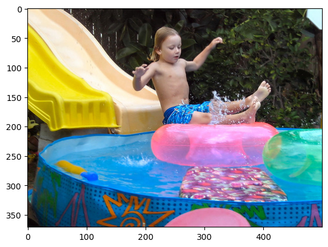

```python
generate_caption("1077546505_a4f6c4daa9.jpg")
```

```
---------------------Actual---------------------
startseq boy in his blue swim shorts at the beach endseq
startseq boy smiles for the camera at beach endseq
startseq young boy in swimming trunks is walking with his arms outstretched on the beach endseq
startseq children playing on the beach endseq
startseq the boy is playing on the shore of an ocean endseq
--------------------Predicted--------------------
startseq boy in his blue swim shorts at the beach endseq
```

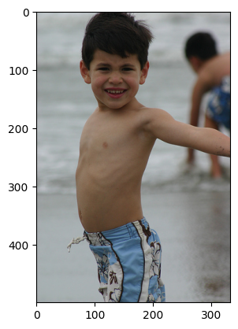

```python
generate_caption("106490881_5a2dd9b7bd.jpg")
```

## Streamlit User-Friendly Version

I've created a user-friendly version of the Image Caption Generator using Streamlit, offering a seamless one-click experience. This version allows users to effortlessly generate the image caption with just a single click.

To explore the Streamlit version, click the button below:

[Generate Image Caption](https://image-caption-generator-brillian.streamlit.app/)